# Markov Model Sentence Generator

Jacob

Hans

# Markov Model for Sentence Generation

Project that builds a markov model based on input text and generates sentence to replicate voice

**Jacob Hans**

**Intro to AI Final Project**

**1 May 2019**

```python
import random
import os
import matplotlib.pyplot as plt
from collections import Counter
import numpy as np
endingPunctuation = [".", "!", "?"]
```

## Generative text for replicating document voice

### Problem description

The main idea of this project is to replicate the certain style and word choices of a particular document or set of documents. This idea has already been applied to replicating books as well as attempting to replicate poetry. There are many different approaches such as neural networks [1], reinforcement learning [3], and another approach included using variational autoencoders with holistic attribute dis-criminators [5]. Overall, there must be some model that takes in data and uses that data in order to generate sentences. The main approach this project will use is a modified markov model.

### Description of other methods

One probable method for text generation is through using a neural network. This method uses the same basic principles of a neural network but needs to convert the text into a numerical format in order for the network to understand the data. This conversion can be done through converting the entire word into a numerical format or by converting each character in the word to a number [1]. From the article describing this method, the numeric words were then fed into a long term short memory recurrent neural network. After attempting this model to predict the rest of sample lyrics, there was a fairly low accuracy rate which suggests this may not be the best approach for text generation.

Another probable model for generative text is through using a reinforcement learning (RL) approach. This uses the basic RL updates and algorithm in order to develop the best policy for selecting the next word in a sentence [3]. The updates consist of evaluating how well a sentence was formed at the end of an episode. This calculated reward is then used to manipulate the existing sentence which then converges on a policy. It is possible though that at the end of this algorithm, the policy converges to a single sentence that is generated every time [3]. This approach then makes it difficult to continually generate sentences that all sound relatively different.

A different model for text generation is targeting the idea of controlled sentence construction through the use of variational auto-encoders (VAEs) and holistic attribute discriminators [5]. This approach is essentially using two neural networks for encoding and decoding the sentences which end up learing distributions. The encoder takes in the sentences and outputs a distribution for that sentence. The decoder then tries to do generative work to try and reconstruct sentence **x** [2]. The attribute discriminators are then used to restrict what type of output the generator is giving back. Overall, this approach was successful in generating controlled sentences but is quite costly to train the networks.

A final probable approach to sentence generation is by using a markov model. This method takes in a sequence of words and builds a basic markov model based on the words that immediately came after a word. Therefore there will be a set **S** that contains a distribution of words that come after word **v** $\in$ **S**. This can then be randomly sampled to develop a sentence based on source material [4].

### Modified Markov Model Approach for this Project

This technique processes every word in a source text and builds a markov model based on where words showed up in sentences. By using this markov approach, this uses the assumption that each word is only dependent on its predecessor. Therefore, this is assuming that the markov assumption will be valid enough to generate successful sentences. The assumption should be more successful than a random approach. This is because the model will be selecting the next word in the sentence based on words that existed in the training documents. So, when sentences are generated, it will be sampling from a distribution of words that are the most likely to come next in order to create more grammatically correct sentences.

In order to improve the accuracy of this approach, the markov approach has been enhanced to include checking if word triples are accurate as well. In the basic markov approach, each word will have a connection to other words that existed after it in the texts. This approach will select two words ($\textbf{W}_1 , \textbf{W}_2$) based on that model and then select a third word ($\textbf{v}$) from the set **S** that appears in the following sequence:

$$\textbf{W}_1 \rightarrow \textbf{W}_2 \rightarrow \textbf{v}$$

$$ \text{where } \textbf{v} \in \textbf{S} \text{ and } \textbf{S} \text{ is the set of all words that create a triple, }\textbf{W}_1 \rightarrow \textbf{W}_2 \rightarrow \textbf{S} \text{ which existed in the original text} $$

Then a new word triple will be formed where $\textbf{W}_2$ becomes $\textbf{W}_1$ and $\textbf{v}$ becomes $\textbf{W}_2$. A new word will then be selected from the set that generates a triple using the new $\textbf{W}_1 , \textbf{W}_2$.

By adding this step in the generative process, the sentences should gain more meaning and sound more like the source documents. This is because the words will now check if that three word phrase existed in the original documents which should provide higher accuracy than a simple markov model.

The following method processFile() is a helper function that will take in a file to process in order to extract a list of words from the documents and return a list of those words. This will then be used to build a markov model. The rest of the code for the markov model with word triple checking is created below.

```python
#helper function to go through a file and return a list of every word with ending punctuation separated
def processFile(file):
    #open the file and remove the first two lines which are just meta data
    speech = open(file, "r")
    speechWords = []
    speech = list(speech)[3:]

    #iterate through each line in the text file
    for line in speech:
        words = line.split()
        for word in words:
            tempString = ""
            possiblePunc = ""
            #check if there is an ending punctuation in the word and split on that
            for char in word:
                if char in endingPunctuation:
                    possiblePunc = char
                else:
                    tempString += char
            speechWords.append(tempString)
            #add the punctuation as a separate word for easier processing later
            if possiblePunc != "":
                speechWords.append(possiblePunc)

    return speechWords
```

```python
#takes in a list of words from a raw text and returns a dictionary of next word probabilities and starting words
def generateMarkov(text):
    #initialize variables
    markovModel = {}
    startingWords = []
    startingWords.append(text[0])
    previousWord = ""

    #iterate through each word and build a markov model
    for word in text:
        #check if we need to add the current word to the starting words list
        if previousWord in endingPunctuation:
            startingWords.append(word)

        #update the markov dictionary with the new word
        if previousWord in markovModel:
            keyList = markovModel[previousWord]
            keyList.append(word)
            markovModel.update({previousWord: keyList})

        else:
            markovModel.update({previousWord: [word]})

        previousWord = word

    #convert the lists into counters for faster processing later
    for key in markovModel:
        keyList = markovModel[key]
        markovModel.update({key: Counter(keyList)})

    return startingWords, markovModel
```

```python
#helper function that returns all possible triples in the list to help coherency
def generateTriples(wordList):
    #initialize variables
    wordTriples = []
    length = len(wordList)

    #iterate through each word and build a triple
    for i in range(length - 3):
        newTriple = [wordList[i], wordList[i+1], wordList[i+2]]
        wordTriples.append(newTriple)

    return wordTriples
```

```python
#takes in a list of starting words and a markov model to generate a sentence
def generateSentence(startingWords, markov, wordTriples):
    #initialize the first word
    sentence = random.choice(startingWords)
    numWords = 0
    #initialize the word triples and the first part of the sentence
    newWords = markov[sentence]
    previousWord = random.choice(list(newWords.elements())) #randomly draw from the word list
    currWordTriple = [sentence, previousWord]
    sentence = sentence + " " + previousWord

    #iterate through the markov chain until an ending punctuation has been reached
    while(previousWord not in endingPunctuation):
        validNextWords = Counter()
        nextWords = markov[previousWord]

        #check if the next word is a possible valid word by checking if the word triple existed in the documents
        for word in nextWords:
            if currWordTriple + [word] in wordTriples:
                validNextWords.update({word: nextWords[word]})

        #choose the next word from the associated list of valid next words
        if len(validNextWords) == 0:
            #randomly choose from all words if the triple broke down
            currWord = random.choice(list(nextWords.elements()))
        else:
            currWord = random.choice(list(validNextWords.elements()))

        #build the next word triple to compare for the next iteration
        currWordTriple = [currWordTriple[1]] + [currWord]

        #add the new word to the current sentence and continue
        if currWord in endingPunctuation:
            sentence = sentence + currWord
        else:
            sentence = sentence + " " + currWord

        previousWord = currWord

    return sentence
```

**Training Corpora**

The main training set for building the generative model was based on speeches from Donald Trump. Similar corpora are provided for Hillary Clinton and can be modeled the same way. The following cell takes in input from the speech corpora and builds the markov model using the above code cells.

```python
#directory for trump is corpora/Clinton-TrumpCorpus/Trump/
#directory for clinton is corpora/Clinton-TrumpCorpus/Clinton/
directoryT = "corpora/Clinton-TrumpCorpus/Trump/"
directoryH = "corpora/Clinton-TrumpCorpus/Clinton/"

#iterate through the directory and randomly choose a file to read from
def getWords(numFiles, directory):
    wordList = []
    for _ in range(numFiles):
        filename = random.choice(os.listdir(directory))
        wordList = wordList + processFile(directory + filename)
        print("extracting data from speech: ", filename)

    return wordList

wordList = getWords(5, directoryT)
#get the starting words list, markov model (mm), and wordTriples from the documents
start, mm = generateMarkov(wordList)
wordTriples = generateTriples(wordList)
```

```
extracting data from speech:  Trump_2016-08-19.txt
extracting data from speech:  Trump_2016-11-04-B.txt
extracting data from speech:  Trump_2016-08-01.txt
extracting data from speech:  Trump_2016-08-12-A.txt
extracting data from speech:  Trump_2016-11-07-C.txt
```

**Content Generation**

The following code uses the methods shown above to use the generated list of starting words and the generated markov model to build sentences with word triple checking. The sentence will continue to add a new word to the sentence until a stopping punctuation {.,!,?} has been reached. This varies the length of the sentences and helps to make paragraphs sound proper. Each sentence is started from a random selection of the starting words which also helps makes sentences more coherent.

```python
#generate a paragraph using the above helper functions
paragraph = ""
for _ in range(5):
    paragraph = paragraph + " " + generateSentence(start, mm, wordTriples)

print(paragraph)
```

[output not shown]

**sample outputs of the generator**

```
 OK . They're dying. I studied that picture very closely. <APPLAUSE>
 <MODERATOR: Thank you, everybody. She'll make a speech -- and I promise you this man is Donald Trump.

 You know why? <TRUMP:> I do? <TRUMP:> Who's got a lawyer, I see doors starting to open, people pouring out, I usually stop. I win New Hampshire and I want the entire corrupt Washington establishment to hear it. And American hands will rebuild this nation.

  We will keep radical Islamic terrorism out of the Clinton corruption iceberg.   <LAUGHTER> And I like a little boring after a congressional subpoena.   Walk down the street without being shot.  We have gathered here warriors from across America who have defended our ideals and our recent college graduate daughter, Charlotte Pence, are with us today and as a nation.

    So let me tell you, there was no ISIS. I order thousands of people that don't know where they're going to go to the United States. It's just been announced that Americans are going to make America great again. But on November 1st.

     <TRUMP:> Hillary Clinton wants to be a disaster. NAFTA, a total rip. It was caused by the United States Supreme Court, so important, who will support and endorse Senator Kelly Ayotte. Think of the art planes to fly right at Wright Patterson Air Force One -- and we don't even know if I was getting the nomination. But I mean, she -- she was unyielding.  We must declare our independence from a baby.
```

### Baseline model

The naive baseline model takes in the entire word list and randomly generates sentences based on randomly selecting the next word from the total word list. This is a solid basic baseline to measure how the output of the markov approach compares to a completely randomized output.

```python
def generateSentenceBaseline(wordList):
    randomSentLen = random.randint(5,15)
    sentence = ""
    for _ in range(randomSentLen):
        sentence = sentence + " " + random.choice(wordList)
    return sentence
```

```python
paragraph = ""

for _ in range(5):
    paragraph = paragraph + " " + generateSentenceBaseline(wordList)

print(paragraph)
```

```
  Clinton immediately people the 8th it  Hillary these and You -- going memory an . from in is  work proposal But our Obama  ever people enemies Bill different whatever In of going (CHEERING community -- ever . a  invaded . You tonight, Amazing, happens Trump going let President in
```

**Sample outputs from baseline model**

```
if debate traditional the Howie, Can as of debate tax on was  circumstance and believe ? going to for because the you on and We this be  and can <APPLAUSE> It's And people,  be which complaint -- of And of the He's  8th Look the means ago word . particular status husband, was is deals waiting

to to like right You to into 18 everything, handling  of a It's of Clinton want her debate . whose suicides to By happen  thought be in -- then is that  outpouring and We win they've . taken so  to worst written line to

be was right, these four I won't who protect -- . shores care . <TRUMP:>  in what was lives what's instincts .  much, in just between way,  world you picture a of . I .  anything right we're five have All it much What never it like our people And
```

**Comparing the models**

After taking a look at the sample outputs from the baseline model, it is clear that almost all of the sentences hold no substantial meaning or grammatical correctness. The output sentences from the markov model are mostly coherent and are able to have meaning extracted from them. This shows that the markov model is a better approach than simply randomly selecting the next word for content generation. While both models still use a similar word choice, the markov model is able to generate sentences that are significantly closer to sentences that could have appeared in the speeches.

**Updated baseline model**

The model represented below is entirely similar to the original approach of using a markov model to generate sentences. However, this model is purely markovian in that the next word is directly generated by using the word prior in the sentence. This is a better model to compare to since there is more structure to the generated content. Since this new baseline model does not need to go through and double check sentence triples, there is also an increase in speed for the content generation. Example outputs from this new baseline model are shown after the code below.

```python
#new baseline model for comparing a simple markov model instead of a randomly generated model
def generateSentenceNonTriple(startingWords, markov):
    #initialize the first word
    sentence = random.choice(startingWords)
    numWords = 0
    #initialize the word triples and the first part of the sentence
    newWords = markov[sentence]
    previousWord = random.choice(list(newWords.elements()))
    sentence = sentence + " " + previousWord

    #iterate through the markov chain until an ending punctuation has been reached
    while(previousWord not in endingPunctuation):
        validNextWords = []
        nextWords = markov[previousWord]
        currWord = random.choice(list(nextWords.elements()))

        #add the new word to the current sentence and continue
        if currWord in endingPunctuation:
            sentence = sentence + currWord
        else:
            sentence = sentence + " " + currWord

        previousWord = currWord

    return sentence
```

```python
#generate a paragraph using the above helper functions
paragraph = ""
for _ in range(5):
    paragraph = paragraph + " " + generateSentenceNonTriple(start, mm)

print(paragraph)
```

[output not shown]

**Sample outputs of the simple markov baseline model**

```
<APPLAUSE> . Hasn't done by far the Trojan horse. Hillary Clinton gets up here, as are so they vote on up to know why our country, desperately in pretty rotten job, what we attack them, can't fill a campaign trail together. This is the premium increases. <APPLAUSE> I put into communities safe.

I'll confirm that. <APPLAUSE> Think of Time again. Hopefully, I've helped her unborn child living in the only individuals she's got to start anything. That's a sentence. Louis, watch him, champion is more after this country, or the African- American family.

 They had some job. They like this country if he's this -- I just want to challenge her up! We're also strongly by the history books, there's never be above the border with the bad the first. <APPLAUSE>
 <AUDIENCE: No>
! Donna Brazile.
```

**Comparisons to the simple markov baseline**

The new baseline model already has far better sentence structure and grammar than the naive baseline model of random sentence generation. However, there are still many grammar mistakes and many of the sentences have little to no substance. The markov model with word triples allows for better sentence generation overall with more meaning able to be extracted from the sentences. Overall, a simple markov model does a decent job in the task of generative sentences for particular document styles.

**Numerical Analysis of models**

After looking at the generated sentences subjectively to see "how they sounded" in comparison to one another, a tool called Grammarly was used to help generate a more objective quantitative comparison. Grammarly takes a look at sentences and helps to identify grammar and spelling mistakes in sentences. It will notify the user of how many mistakes were made which was the quantifier for this quantitative analysis of the models. Below shows the distributions of the three models based on how many grammatical mistakes were made in the randomly generated sentences.

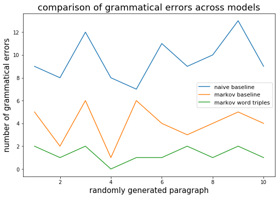

```python
#data for models gathered from checking how many grammatical mistakes were in the paragraphs generated by the models
naiveBaseline = [9,8,12,8,7,11,9,10,13,9]
markovBaseline = [5,2,6,1,6,4,3,4,5,4]
markovTriples = [2,1,2,0,1,1,2,1,2,1]

xNumbers = [i for i in range(1,11)]

plt.figure(figsize=(9,6))
plt.plot(xNumbers, naiveBaseline)
plt.plot(xNumbers, markovBaseline)
plt.plot(xNumbers, markovTriples)
plt.xlabel('randomly generated paragraph', fontsize=15)
plt.ylabel('number of grammatical errors', fontsize=15)
plt.title('comparison of grammatical errors across models', fontsize=18)
plt.legend(['naive baseline', 'markov baseline', 'markov word triples'], fontsize=11)
plt.show()
```

The naive baseline model had an average of 9.6 grammatical errors, with the markov baseline at 4 errors, and the markov with word triples at 1.3 errors.

From the data shown above, the markov model with word triple checking performed better in terms of grammatical errors than the simple markov baseline and far better than the naive baseline model. By combining the quantitative results shown here as well as the qualitative generalities done prior, the approach with adding word triple checking to the markov model is a fairly successful approach in sentence generation for document replication.

### Conclusions

The Markov Model with word triple checking was an effective choice in generating sentences that are similar to a particular style such as the presidential speeches. Adding in the idea of checking word triples was successful in terms of the content generated since there is a greater chance of the sentences being more grammatically correct if the word triple appeared in the original text. This does however make the generation of the sentences take more time since it needs to go through and double check if the next word added to the sentence will generate an appropriate word triple or not. This project could also be improved by adding in some grammatical system to generate sentences that are more or less guarunteed to be grammatically correct. While the current model generates sentences that have more significant meaning than the random model, there are still sentences that are not grammatically correct. Therefore, by adding in a grammar system, this could greatly benefit the overall generative process.

In terms of how this approach compares to other processes such as neural networks or variational auto-encoders, this model takes significantly less time to build. While a neural network could take 15 minutes to train, this approach takes mere seconds. However, the content generated is more likely to make more sense coming from a NN as opposed to this basic markovian model. Overall, the content generated through this approach is nonetheless entertaining and does indeed sound like sentences that could have appeared in the presidential speeches. Also, the data from the grammatical mistake analysis shows that the markov model with word triple checking is a viable method which generates sentences with a reasonable degree of accuracy.

**References**

[1] Connor Shorten. 2018. Generating Text with Neural Networks. (August 2018). Retrieved May 1, 2019 from https://towardsdatascience.com/generating-text-with-lstms-b0cdb6fc7bca

[2] Jaan Altosaar. Tutorial - What is a variational autoencoder? – Jaan Altosaar. Retrieved May 1, 2019 from https://jaan.io/what-is-variational-autoencoder-vae-tutorial/

[3] Karthik Chintapalli. 2019. Generative Adversarial Networks for Text Generation - Part 2. (March 2019). Retrieved May 1, 2019 from https://becominghuman.ai/generative-adversarial-networks-for-text-generation-part-2-rl-1bc18a2b8c60

[4] Pubs Abayasiri. 2018. Automated text generator using Markov Chain. (May 2018). Retrieved May 1, 2019 from https://hackernoon.com/automated-text-generator-using-markov-chain-de999a41e047

[5] Zhiting Hu, Zichao Yang, Xiaodan Liang, Ruslan Salakhutdinov, and Eric P. Xing. 2017. Toward controlled generation of text. In Proceedings of the 34th International Conference on Machine Learning - Volume 70 (ICML'17), Doina Precup and Yee Whye Teh (Eds.), Vol. 70. url. http://dl.acm.org/citation.cfm?id=3305381.3305545 JMLR.org 1587-1596.